# Assignment 2: Hand Gesture Recognition [50 Pt]

## Part 2. Model Building and Sanity Checking [4pt]

### Part (i) Convolutional Network [2pt MODEL]

Build a convolutional neural network model that takes the (224x224 RGB) image as input, and predicts the gesture letter. Your model should be a subclass of nn.Module. Explain your choice of neural network architecture: how many layers did you choose? What types of layers did you use? Were they fully-connected or convolutional? What about other decisions like pooling layers, activation functions, number of channels / hidden units?

```python
class SignLanguageClassifier(nn.Module):
    def __init__(self):
        super(SignLanguageClassifier, self).__init__()
        self.conv1 = nn.Conv2d(3, 64, 3, padding=1)
        self.bn1 = nn.BatchNorm2d(64)

        self.conv2 = nn.Conv2d(64, 128, 3, padding=1)
        self.bn2 = nn.BatchNorm2d(128)

        self.conv3 = nn.Conv2d(128, 256, 3, padding=1)
        self.bn3 = nn.BatchNorm2d(256)

        self.conv4 = nn.Conv2d(256, 512, 3, padding=1)
        self.bn4 = nn.BatchNorm2d(512)

        self.pool = nn.MaxPool2d(2, 2)
        self.global_pool = nn.AdaptiveAvgPool2d((1, 1))

        self.fc1 = nn.Linear(512, 128)
        self.fc2 = nn.Linear(128, 9)

    def forward(self, x):
        x = self.pool(F.relu(self.bn1(self.conv1(x))))
        x = self.pool(F.relu(self.bn2(self.conv2(x))))
        x = self.pool(F.relu(self.bn3(self.conv3(x))))
        x = self.pool(F.relu(self.bn4(self.conv4(x))))
        x = self.global_pool(x)
        x = x.view(x.shape[0], -1)
        x = F.relu(self.fc1(x))
        x = self.fc2(x)
        return x
```

```python
'''
PROVIDE YOUR ANSWER BELOW
The SignLanguageClassifier is a deep CNN designed to classify 224×224 RGB images into 9 gesture classes.
It consists of four convolutional layers (3×3 filters, increasing channels: 64 → 128 → 256 → 512), each followed by Batch Normalization and
MaxPooling (2×2) to stabilize training and reduce spatial dimensions efficiently.
Adaptive Average Pooling (1×1) compresses the feature maps before feeding them into two fully connected layers (512 → 128 → 9) for classification.
ReLU activations enhance non-linearity, preventing vanishing gradients, while CrossEntropyLoss handles softmax internally.
'''
```

```python
from torchvision import models
small_train_loader = torch.utils.data.DataLoader(train_data, batch_size=64, shuffle=True)

# model = models.resnet18(pretrained=True)
# num_ftrs = model.fc.in_features
# model.fc = nn.Linear(num_ftrs, 9)  # Adjust output for 9 classes
# model = model.cuda()
torch.cuda.empty_cache()

model = SignLanguageClassifier().cuda()
optimizer = torch.optim.Adam(model.parameters(), lr=0.001)
criterion = nn.CrossEntropyLoss()

for epoch in range(5):  # Only 5 epochs
    for i, (imgs, labels) in enumerate(small_train_loader):
        if i > 2:  # Only use first 3 batches
            break
        imgs, labels = imgs.cuda(), labels.cuda()
        optimizer.zero_grad()
        outputs = model(imgs)
        loss = criterion(outputs, labels)
        loss.backward()
        optimizer.step()
    print(f"Epoch {epoch+1}, Loss: {loss.item()}")

# Check predictions
for imgs, labels in small_train_loader:
    imgs = imgs.cuda()
    outputs = model(imgs)
    print("Predictions:", outputs.argmax(1).cpu().numpy())
    print("True Labels:", labels.numpy())
    break
```

```python
from torchvision import models
# Define Data Paths
data_dir = 'Processed_Lab_3b_Gesture_Dataset Revised'
train_dir = os.path.join(data_dir, 'train/')
val_dir = os.path.join(data_dir, 'valid/')
test_dir = os.path.join(data_dir, 'test/')
torch.cuda.empty_cache()
# Image Preprocessing (IMPORTANT: Normalize!)
data_transform = transforms.Compose([
    transforms.Resize((224, 224)),
    transforms.ToTensor(),
    transforms.Normalize(mean=[0.5], std=[0.5])  # Normalize for pretrained model
])

# Load Dataset
train_data = datasets.ImageFolder(train_dir, transform=data_transform)

# Small Dataloader for Sanity Check (First 3 Batches)
small_train_loader = DataLoader(train_data, batch_size=64, shuffle=True)

# Load Pretrained ResNet18
# model = models.resnet18(pretrained=True)
# num_ftrs = model.fc.in_features
# model.fc = nn.Linear(num_ftrs, 9)  # Adjust output for 9 classes

model = SignLanguageClassifier()
# Move Model to GPU (if available)
device = torch.device("cuda" if torch.cuda.is_available() else "cpu")
model = model.to(device)

# Loss & Optimizer
optimizer = optim.Adam(model.parameters(), lr=0.003)
criterion = nn.CrossEntropyLoss()

# Training for Sanity Check (Only 3 Batches)
for epoch in range(5):
    for i, (imgs, labels) in enumerate(small_train_loader):
        if i > 2:  # Only use first 3 batches
            break

        imgs, labels = imgs.to(device), labels.to(device)
        optimizer.zero_grad()
        outputs = model(imgs)
        loss = criterion(outputs, labels)
        loss.backward()
        optimizer.step()

    print(f"Epoch {epoch+1}, Loss: {loss.item():.4f}")

# Check Predictions (Sanity Check)
correct, total = 0, 0
for imgs, labels in small_train_loader:
    imgs = imgs.to(device)
    outputs = model(imgs)

    # Predictions
    preds = outputs.argmax(1).detach().cpu().numpy()
    true_labels = labels.numpy()

    correct += (preds == true_labels).sum()
    total += labels.size(0)

    print("Predictions:", preds)
    print("True Labels:", true_labels)
    break  # Stop after 1 batch

print(f"Sanity Check Accuracy: {correct/total:.2%}")
```

[output not shown]

### Part (ii) Training Code [1pt MODEL]

Write code that trains your neural network given some training data. Your training code should make it easy to tweak the usual hyperparameters, like batch size, learning rate, and the model object itself. Make sure that you are checkpointing your models from time to time (the frequency is up to you). Explain your choice of loss function and optimizer.

```python
def get_accuracy(model, train=False):
    # Use the correct DataLoader
    loader = train_loader if train else val_loader

    correct = 0
    total = 0

    with torch.no_grad():
        for imgs, labels in loader:  # Use train_loader or val_loader
            # To Enable GPU Usage
            if use_cuda and torch.cuda.is_available():
                imgs = imgs.cuda()
                labels = labels.cuda()

            output = model(imgs)
            pred = output.argmax(1)  # Get class predictions

            correct += (pred == labels).sum().item()
            total += imgs.shape[0]

            # Print first 5 predictions for debugging
            print("Predictions:", pred[:10].cpu().numpy())
            print("True Labels:", labels[:10].cpu().numpy())

    return correct / total
```

```python
# TO BE COMPLETED
def train(model, data, batch_size=64, num_epochs=1, lr=0.005):
    train_loader = torch.utils.data.DataLoader(data, batch_size=batch_size, shuffle=True, num_workers=0, pin_memory=True)
    loss_function = nn.CrossEntropyLoss()
    optimizer = optim.Adam(model.parameters(), lr=lr)

    iters, losses, train_acc, val_acc = [], [], [], []

    # training
    n = 0 # the number of iterations
    for epoch in range(num_epochs):
        for batch_idx, (imgs, labels) in enumerate(train_loader):
            #To Enable GPU Usage
            if use_cuda and torch.cuda.is_available():
              imgs = imgs.cuda()
              labels = labels.cuda()
            print(f"Batch {batch_idx}: {labels.cpu().numpy()}")
            if batch_idx == 5: break  # Stop after 5 batches
            out = model(imgs)             # forward pass
            loss = loss_function(out, labels) # compute the total loss
            loss.backward()               # backward pass (compute parameter updates)
            # for name, param in model.named_parameters():
            #   if param.grad is not None:
            #       print(f"{name}: Mean Grad = {param.grad.abs().mean().item()}")
            optimizer.step()              # make the updates for each parameter
            optimizer.zero_grad()         # a clean up step for PyTorch
            if batch_idx % 10 == 0:  # Print loss every 10 batches
              print(f"Batch {batch_idx}, Loss: {loss.item()}")
            # save the current training information
            iters.append(n)
            losses.append(float(loss)/batch_size)             # compute *average* loss
            train_acc.append(get_accuracy(model, train=True)) # compute training accuracy
            val_acc.append(get_accuracy(model, train=False))  # compute validation accuracy
            n += 1

    # plotting
    plt.title("Training Curve")
    plt.plot(iters, losses, label="Train")
    plt.xlabel("Iterations")
    plt.ylabel("Loss")
    plt.show()

    plt.title("Training Curve")
    plt.plot(iters, train_acc, label="Train")
    plt.plot(iters, val_acc, label="Validation")
    plt.xlabel("Iterations")
    plt.ylabel("Training Accuracy")
    plt.legend(loc='best')
    plt.show()

    print("Final Training Accuracy: {}".format(train_acc[-1]))
    print("Final Validation Accuracy: {}".format(val_acc[-1]))
```

```python
use_cuda = True
torch.backends.cudnn.benchmark = True

model = SignLanguageClassifier()

if use_cuda and torch.cuda.is_available():
  model.cuda()
  print('CUDA is available!  Training on GPU ...')
else:
  print('CUDA is not available.  Training on CPU ...')

#proper model
train(model, train_data, num_epochs=2, lr=1)
```

[output not shown]

```python
'''
PROVIDE YOUR ANSWER BELOW
'''
```

### Part (iii) “Overfit” to a Small Dataset - [1pt MODEL]

One way to sanity check our neural network model and training code is to check whether the model is capable of “overfitting” or “memorizing” a small dataset. A properly constructed CNN with correct training code should be able to memorize the answers to a small number of images quickly.

Construct a small dataset (e.g. just the images that you have collected). Then show that your model and training code is capable of memorizing the labels of this small data set.

With a large batch size (e.g. the entire small dataset) and learning rate that is not too high, you should be able to obtain a 100% training accuracy on that small dataset relatively quickly (within 200 iterations).

```python
# TO BE COMPLETED
```

## Part 3. Hyperparameter Search [7pt]

### Part (i) - [2pt EXPLORATORY]

List 3 hyperparameters that you think are most worth tuning. Choose at least one hyperparameter related to the model architecture.

```python
'''
PROVIDE YOUR ANSWER BELOW
The 3 hyperparameters I think matte the most are:
1. Learning rate (relates to the architecture in the Adam optimizer)
2. Batch size
3. Number of epochs
'''
```

### Part (ii) - [1pt MODEL]

Tune the hyperparameters you listed in Part (i), trying as many values as you need to until you feel satisfied that you are getting a good model. Plot the training curve of at least 4 different hyperparameter settings.

```python
# TO BE COMPLETED
```

### Part (iii) - [2pt DISCUSSION]

Choose the best model out of all the ones that you have trained. Justify your choice.

```python
'''
PROVIDE YOUR ANSWER BELOW
'''
```

### Part (iv) - [2pt RESULTS]

Report the test accuracy of your best model. You should only do this step once and prior to this step you should have only used the training and validation data.

Additionally, provide a confusion matrix to visualize the performance of your model across different classes.

```python
# TO BE COMPLETED
```

```python
'''
PROVIDE YOUR ANSWER BELOW
'''
```

## Part 4. Transfer Learning [8pt]

For many image classification tasks, it is generally not a good idea to train a very large deep neural network model from scratch due to the enormous compute requirements and lack of sufficient amounts of training data.

One of the better options is to try using an existing model that performs a similar task to the one you need to solve. This method of utilizing a pre-trained network for other similar tasks is broadly termed **Transfer Learning**. In this assignment, we will use Transfer Learning to extract features from the hand gesture images. Then, train a smaller network to use these features as input and classify the hand gestures.

As you have learned from the CNN lecture, convolution layers extract various features from the images which get utilized by the fully connected layers for correct classification. AlexNet architecture played a pivotal role in establishing Deep Neural Nets as a go-to tool for image classification problems and we will use an ImageNet pre-trained AlexNet model to extract features in this assignment.

### Part (i) - [1pt EXPLORATORY]

Here is the code to load the AlexNet network, with pretrained weights. When you first run the code, PyTorch will download the pretrained weights from the internet.

```python
import torchvision.models
alexnet = torchvision.models.alexnet(pretrained=True)
```

The alexnet model is split up into two components: *alexnet.features* and *alexnet.classifier*. The first neural network component, *alexnet.features*, is used to compute convolutional features, which are taken as input in *alexnet.classifier*.

The neural network alexnet.features expects an image tensor of shape Nx3x224x224 as input and it will output a tensor of shape Nx256x6x6 . (N = batch size).

Compute the AlexNet features for each of your training, validation, and test data. Here is an example code snippet showing how you can compute the AlexNet features for some images (your actual code might be different):

**Save the computed features**. You will be using these features as input to your neural network in Part (ii), and you do not want to re-compute the features every time. Instead, run *alexnet.features* once for each image, and save the result.

```python
# Load pretrained AlexNet
alexnet = models.alexnet(pretrained=True)
feature_extractor = alexnet.features  # Extract convolutional layers
feature_extractor.eval()  # Set to evaluation mode

device = torch.device("cuda" if torch.cuda.is_available() else "cpu")
feature_extractor.to(device)

# Define image transformations (resize + normalize)
transform = transforms.Compose([
    transforms.Resize((224, 224)),  # AlexNet input size
    transforms.ToTensor(),
    transforms.Normalize(mean=[0.485, 0.456, 0.406], std=[0.229, 0.224, 0.225])
])

# Define root folder containing subfolders
root_folder = r"C:\Users\Austin\Documents\MEng_Courses\MIE1517-Intro-to-Deep-Learning\2_Assignments\A2_CNN\Lab_3b_Gesture_Dataset Revised"
feature_dict = {}

# Recursively scan through subfolders
for subdir, _, files in os.walk(root_folder):
    for filename in files:
        if filename.endswith(".jpg"):
            img_path = os.path.join(subdir, filename)

            # Remove the first-level subfolder
            relative_path = os.path.relpath(img_path, root_folder)
            cleaned_path = "/".join(relative_path.split(os.sep)[1:])  # Remove first folder name (e.g., "A/")

            # Load and transform image
            image = Image.open(img_path).convert("RGB")
            image = transform(image).unsqueeze(0).to(device)  # Add batch dimension

            # Extract features
            with torch.no_grad():
                features = feature_extractor(image)  # Get feature maps (1, 256, 6, 6)
                features = features.squeeze(0).cpu().numpy()  # Preserve (256, 6, 6) shape

            # Store features using the cleaned filename
            feature_dict[cleaned_path] = features
np.savez("image_features_Alex.npz", **feature_dict)
```

```python
import torch
import numpy as np
from torch.utils.data import Dataset

class FeatureDataset(Dataset):
    def __init__(self, feature_file, selected_filenames):
        self.features = np.load(feature_file, allow_pickle=True)  #
        self.file_keys = list(self.features.keys())  # Get all stored filenames

        # Filter only the filenames belonging to the selected split
        self.filtered_keys = [f for f in self.file_keys if f in selected_filenames]

        # Define a mapping from letter labels to numeric labels
        self.label_mapping = {char: idx for idx, char in enumerate("ABCDEFGHI")}  # 'A' -> 0, 'B' -> 1, ..., 'I' -> 8

    def __len__(self):
        return len(self.filtered_keys)

    def __getitem__(self, idx):
        file_name = self.filtered_keys[idx]  # Get filename
        feature = self.features[file_name]  # Get corresponding feature vector

        # Extract class label from filename (assumed format: "PersonID_ClassID_Extra.jpg")
        class_label_letter = file_name.split("_")[1]  # Extract the letter (e.g., 'A', 'B', ..., 'I')
        class_label = self.label_mapping[class_label_letter]  # Convert letter to number

        return torch.tensor(feature, dtype=torch.float32), torch.tensor(class_label, dtype=torch.long)
```

```python
import random
from collections import defaultdict

# Organize images by class and person ID
class_person_images = defaultdict(lambda: defaultdict(list))
feature_file = "image_features_Alex.npz"
for class_name in os.listdir(dataset_path):
    class_path = os.path.join(dataset_path, class_name)
    if os.path.isdir(class_path):
        for image in os.listdir(class_path):
            if image.endswith(".jpg"):
                person_id = image.split("_")[0]  # Extract person ID from filename
                class_person_images[class_name][person_id].append(image)

# Split per class instead of only per person ID
train_filenames, valid_filenames, test_filenames = [], [], []

for class_name, person_images in class_person_images.items():
    person_ids = list(person_images.keys())
    random.shuffle(person_ids)

    len_train = int(len(person_ids) * train_ratio)
    len_valid = int(len(person_ids) * valid_ratio)

    for person_id in person_ids[:len_train]:
        train_filenames.extend(person_images[person_id])

    for person_id in person_ids[len_train:len_train + len_valid]:
        valid_filenames.extend(person_images[person_id])

    for person_id in person_ids[len_train + len_valid:]:
        test_filenames.extend(person_images[person_id])

# Create datasets with correctly assigned filenames
train_dataset = FeatureDataset(feature_file, train_filenames)
valid_dataset = FeatureDataset(feature_file, valid_filenames)
test_dataset = FeatureDataset(feature_file, test_filenames)
```

### Part (ii) - [1pt MODEL]

Build a convolutional neural network that takes as input these AlexNet features, and makes a prediction using additional convolutional and/or linear layers. Your model should be a subclass of nn.Module.

Explain your choice of neural network architecture: how many layers did you choose? What types of layers did you use: fully-connected or convolutional? What about other decisions like pooling layers, activation functions, number of channels / hidden units in each layer?

Here is an example of how your model may be called:

```python
# TO BE COMPLETED
class AlexNetFeatureClassifier(nn.Module):
    def __init__(self):
        super(AlexNetFeatureClassifier, self).__init__()
        self.conv1 = nn.Conv2d(in_channels=256, out_channels=128, kernel_size=3, stride=1, padding=1)
        self.conv2 = nn.Conv2d(in_channels=128, out_channels=64, kernel_size=3, stride=1, padding=1)
        self.relu = nn.ReLU()
        self.pool = nn.AdaptiveAvgPool2d((6, 6))
        self.fc1 = nn.Linear(64 * 6 * 6, 256)
        self.fc2 = nn.Linear(256, 9)

    def forward(self, x):
        x = self.relu(self.conv1(x))
        x = self.relu(self.conv2(x))
        x = self.pool(x)
        x = torch.flatten(x, start_dim=1)
        x = self.relu(self.fc1(x))
        x = self.fc2(x)
        return x
```

```python
'''
PROVIDE YOUR ANSWER BELOW
The additional layers were build upon the output of the AlexNet's features. I added two convolution layers (kernel size = 3, 256 -> 128 ->
64 channels) with ReLU activation and adaptive average pooling to maintain spatial consistency.
Next, the feature maps were flattened and feeded into 2 fully connected layers (256 -> 9) to classify the 9 characters.
'''
```

### Part (iii) - [1pt MODEL]

Train your new network, including any hyperparameter tuning. Plot and submit the training curve of your best model only.

Note: Depending on how you are caching (saving) your AlexNet features, PyTorch might still be tracking updates to the **AlexNet weights**, which we are not tuning. One workaround is to convert your AlexNet feature tensor into a numpy array, and then back into a PyTorch tensor.

```python
import seaborn as sns
from sklearn.metrics import confusion_matrix, classification_report
def train(model, dataset, val_dataset=None, num_epochs=10, learning_rate=0.001, batch_size=32, train=True, device=None):
    # Set device (default to GPU if available)
    if device is None:
        device = torch.device("cuda" if torch.cuda.is_available() else "cpu")

    model.to(device)

    # Create DataLoader (shuffle only if training)
    data_loader = DataLoader(dataset, batch_size=batch_size, shuffle=train)

    if train:
        val_loader = DataLoader(val_dataset, batch_size=batch_size, shuffle=False)

        # Define loss and optimizer
        criterion = nn.CrossEntropyLoss()
        optimizer = optim.Adam(model.parameters(), lr=learning_rate)

        train_losses = []
        val_losses = []
        val_accuracies = []

        # Training loop
        for epoch in range(num_epochs):
            model.train()
            total_train_loss = 0

            for features, labels in data_loader:
                features, labels = features.to(device), labels.to(device)

                # Reshape back to (batch_size, 256, 6, 6) for Conv2D layers
                features = features.view(features.size(0), 256, 6, 6)

                # Forward pass
                outputs = model(features)
                loss = criterion(outputs, labels)

                # Backward pass
                optimizer.zero_grad()
                loss.backward()
                optimizer.step()

                total_train_loss += loss.item()

            # Compute average training loss
            avg_train_loss = total_train_loss / len(data_loader)
            train_losses.append(avg_train_loss)

            # Validation phase
            model.eval()
            total_val_loss = 0
            correct = 0
            total = 0

            with torch.no_grad():
                for features, labels in val_loader:
                    features, labels = features.to(device), labels.to(device)
                    features = features.view(features.size(0), 256, 6, 6)  # Ensure correct shape

                    # Forward pass
                    outputs = model(features)
                    loss = criterion(outputs, labels)
                    total_val_loss += loss.item()

                    # Compute accuracy
                    _, predicted = torch.max(outputs, 1)
                    correct += (predicted == labels).sum().item()
                    total += labels.size(0)

            avg_val_loss = total_val_loss / len(val_loader)
            val_losses.append(avg_val_loss)
            val_accuracy = correct / total * 100
            val_accuracies.append(val_accuracy)

            print(f"Epoch [{epoch+1}/{num_epochs}] - Train Loss: {avg_train_loss:.4f}, Val Loss: {avg_val_loss:.4f}, Val Acc: {val_accuracy:.2f}%")

        # Plot training curves
        plt.figure(figsize=(10, 5))

        # Plot Loss Curve
        plt.subplot(1, 2, 1)
        plt.plot(range(1, num_epochs+1), train_losses, label="Train Loss")
        plt.plot(range(1, num_epochs+1), val_losses, label="Val Loss")
        plt.xlabel("Epoch")
        plt.ylabel("Loss")
        plt.title("Training & Validation Loss")
        plt.legend()

        # Plot Accuracy Curve
        plt.subplot(1, 2, 2)
        plt.plot(range(1, num_epochs+1), val_accuracies, label="Val Accuracy", color="green")
        plt.xlabel("Epoch")
        plt.ylabel("Accuracy (%)")
        plt.title("Validation Accuracy")
        plt.legend()
        plt.show()

        torch.cuda.empty_cache()
        return model  # Return trained model

    else:
        # Evaluation mode
        model.eval()
        correct = 0
        total = 0
        all_preds, all_labels = [], []

        with torch.no_grad():  # No gradients needed
            for features, labels in data_loader:
                features, labels = features.to(device), labels.to(device)

                # Reshape features back to (batch_size, 256, 6, 6)
                features = features.view(features.size(0), 256, 6, 6)

                # Forward pass
                outputs = model(features)
                _, predicted = torch.max(outputs, 1)  # Get class with highest probability

                # Compute accuracy
                correct += (predicted == labels).sum().item()
                total += labels.size(0)

                all_preds.extend(predicted.cpu().numpy())
                all_labels.extend(labels.cpu().numpy())

        accuracy = correct / total * 100
        print(f"Test Accuracy: {accuracy:.2f}%")

        # Compute confusion matrix
        cm = confusion_matrix(all_labels, all_preds)
        class_names = ["A", "B", "C", "D", "E", "F", "G", "H", "I"]

        # Normalize confusion matrix
        cm_normalized = cm.astype("float") / cm.sum(axis=1)[:, np.newaxis]

        # Plot confusion matrix
        plt.figure(figsize=(8, 6))
        sns.heatmap(cm_normalized, annot=True, fmt=".2f", cmap="Blues", xticklabels=class_names, yticklabels=class_names)
        plt.xlabel("Predicted Label")
        plt.ylabel("True Label")
        plt.title("Confusion Matrix (Normalized)")
        plt.show()
        return accuracy
```

```
Epoch [1/10] - Train Loss: 2.0612, Val Loss: 1.7952, Val Acc: 49.58%
Epoch [2/10] - Train Loss: 1.3581, Val Loss: 1.0590, Val Acc: 75.00%
Epoch [3/10] - Train Loss: 0.8055, Val Loss: 0.7817, Val Acc: 77.08%
Epoch [4/10] - Train Loss: 0.5843, Val Loss: 0.6365, Val Acc: 81.88%
Epoch [5/10] - Train Loss: 0.4399, Val Loss: 0.6008, Val Acc: 83.33%
Epoch [6/10] - Train Loss: 0.3666, Val Loss: 0.5382, Val Acc: 83.33%
Epoch [7/10] - Train Loss: 0.3065, Val Loss: 0.5148, Val Acc: 84.79%
Epoch [8/10] - Train Loss: 0.2632, Val Loss: 0.5492, Val Acc: 83.12%
Epoch [9/10] - Train Loss: 0.2708, Val Loss: 0.5051, Val Acc: 83.96%
Epoch [10/10] - Train Loss: 0.2101, Val Loss: 0.4856, Val Acc: 85.21%
```

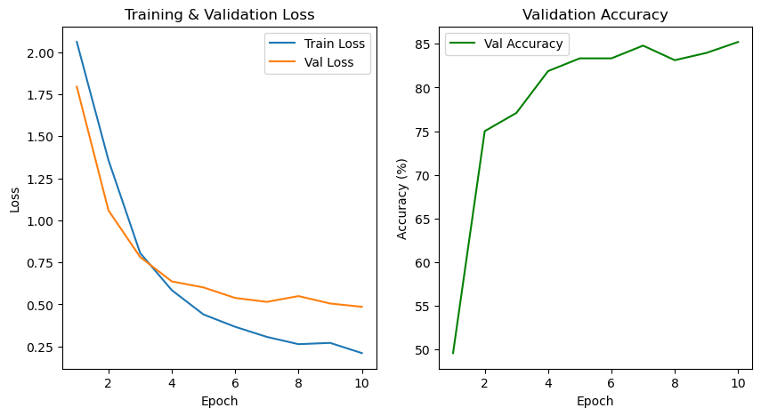

```python
# Initialize model
device = torch.device("cuda" if torch.cuda.is_available() else "cpu")
model = AlexNetFeatureClassifier().to(device)

# Train with train dataset
trained_model = train(model=model, dataset=train_dataset, val_dataset=valid_dataset, num_epochs=10, learning_rate=0.0001, batch_size=96, train=True)
```

### Part (iv) - [1pt RESULTS]

Report the test accuracy of your best model. How does the test accuracy compare to Part 3(iv) without transfer learning?

Additionally, provide a confusion matrix to visualize the performance of your model across different classes.

```
Test Accuracy: 88.19%
```

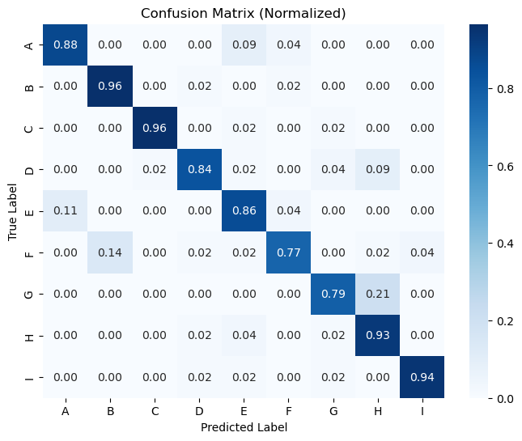

```python
# TO BE COMPLETED
# Test the trained model
test_accuracy = train(model=trained_model, dataset=test_dataset, batch_size=32, train=False)
```

```python
'''
PROVIDE YOUR ANSWER BELOW
'''
```

### Part (v) - Transfer Learning with Another Pretrained Model [1pts EXPLORATORY]

In this section, you will repeat the steps performed in Parts B4(i) to B4(iv) using another pretrained model available in torchvision.models. The goal is to compare the results obtained with AlexNet to those obtained with another model, such as VGG16 or ResNet18 (you can choose your model/s of interest).

```python
# TO BE COMPLETED
## Load the model/s of interest
from PIL import Image

# Load pretrained AlexNet
VGGnet = models.vgg16(pretrained=True)
feature_extractor = VGGnet.features  # Extract convolutional features
feature_extractor.eval()  # Set to evaluation mode

device = torch.device("cuda" if torch.cuda.is_available() else "cpu")
feature_extractor.to(device)

# Define image transformations (resize + normalize)
transform = transforms.Compose([
    transforms.Resize((224, 224)),  # VGGnet input size
    transforms.ToTensor(),
    transforms.Normalize(mean=[0.485, 0.456, 0.406], std=[0.229, 0.224, 0.225])  # ImageNet normalization
])

root_folder = r"C:\Users\Austin\Documents\MEng_Courses\MIE1517-Intro-to-Deep-Learning\2_Assignments\A2_CNN\Lab_3b_Gesture_Dataset Revised"
feature_dict = {}

# Recursively scan through subfolders
for subdir, _, files in os.walk(root_folder):
    for filename in files:
        if filename.endswith((".jpg")):
            img_path = os.path.join(subdir, filename)

            # Remove the first-level subfolder
            relative_path = os.path.relpath(img_path, root_folder)
            cleaned_path = "/".join(relative_path.split(os.sep)[1:])  # Remove first folder name (e.g., "A/")

            # Load and transform image
            image = Image.open(img_path).convert("RGB")
            image = transform(image).unsqueeze(0).to(device)

            # Extract features
            with torch.no_grad():
                features = feature_extractor(image)  # Get feature maps
                features = features.view(features.size(0), -1).cpu().numpy()  # Flatten and move to CPU

            # Store features using the cleaned filename
            feature_dict[cleaned_path] = features[0]

# Save extracted features
np.savez("image_features_UGG.npz", **feature_dict)
```

```python
class FeatureDataset(Dataset):
    def __init__(self, feature_file, selected_filenames):
        self.features = np.load(feature_file, allow_pickle=True)  # Load .npz file
        self.file_keys = list(self.features.keys())  # Get all stored filenames

        # Filter only the filenames belonging to the selected split
        self.filtered_keys = [f for f in self.file_keys if f in selected_filenames]

        # Define a mapping from letter labels to numeric labels
        self.label_mapping = {char: idx for idx, char in enumerate("ABCDEFGHI")}  # 'A' -> 0, 'B' -> 1, ..., 'I' -> 8

    def __len__(self):
        return len(self.filtered_keys)

    def __getitem__(self, idx):
        file_name = self.filtered_keys[idx]  # Get filename
        feature = self.features[file_name]  # Get corresponding feature vector

        # Extract class label from filename (assumed format: "PersonID_ClassID_Extra.jpg")
        class_label_letter = file_name.split("_")[1]  # Extract the letter (e.g., 'A', 'B', ..., 'I')
        class_label = self.label_mapping[class_label_letter]  # Convert letter to number

        return torch.tensor(feature, dtype=torch.float32), torch.tensor(class_label, dtype=torch.long)
```

```python
# Organize images by class and person ID
class_person_images = defaultdict(lambda: defaultdict(list))
feature_file = "image_features_UGG.npz"
for class_name in os.listdir(dataset_path):
    class_path = os.path.join(dataset_path, class_name)
    if os.path.isdir(class_path):
        for image in os.listdir(class_path):
            if image.endswith(".jpg"):
                person_id = image.split("_")[0]  # Extract person ID from filename
                class_person_images[class_name][person_id].append(image)

# Split per class instead of only per person ID
train_filenames, valid_filenames, test_filenames = [], [], []

for class_name, person_images in class_person_images.items():
    person_ids = list(person_images.keys())
    random.shuffle(person_ids)

    len_train = int(len(person_ids) * train_ratio)
    len_valid = int(len(person_ids) * valid_ratio)

    for person_id in person_ids[:len_train]:
        train_filenames.extend(person_images[person_id])

    for person_id in person_ids[len_train:len_train + len_valid]:
        valid_filenames.extend(person_images[person_id])

    for person_id in person_ids[len_train + len_valid:]:
        test_filenames.extend(person_images[person_id])

# Create datasets with correctly assigned filenames
train_dataset = FeatureDataset(feature_file, train_filenames)
valid_dataset = FeatureDataset(feature_file, valid_filenames)
test_dataset = FeatureDataset(feature_file, test_filenames)
```

### Part (vi) - [1pt MODEL]

Build a convolutional neural network model that makes predictions based on features extracted by your model of interest in Part B4(v). Your model should be a subclass of nn.Module.

Explain your choice of neural network architecture.

```python
class VGGNetFeatureClassifier(nn.Module):
    def __init__(self, num_classes=9):
        super(VGGNetFeatureClassifier, self).__init__()
        self.fc1 = nn.Linear(25088, 4096)
        self.fc2 = nn.Linear(4096, 1024)
        self.fc3 = nn.Linear(1024, num_classes)
        self.relu = nn.ReLU()

    def forward(self, x):
        x = self.relu(self.fc1(x))
        x = self.relu(self.fc2(x))
        x = self.fc3(x)
        return x
```

```python
'''
PROVIDE YOUR ANSWER BELOW
Since the output of the VGGNet is already flattened, we just have to add few fully connected layers to perform the classification task.
'''
```

### Part (vii) - [1pt MODEL]

Train your new network, including any hyperparameter tuning. Plot and submit the training curve of your best model only.

```python
def train(model, dataset, val_dataset=None, num_epochs=10, learning_rate=0.001, batch_size=32, train=True, device=None):
    if device is None:
        device = torch.device("cuda" if torch.cuda.is_available() else "cpu")

    model.to(device)
    data_loader = DataLoader(dataset, batch_size=batch_size, shuffle=train)

    if train:
        val_loader = DataLoader(val_dataset, batch_size=batch_size, shuffle=False)

        criterion = torch.nn.CrossEntropyLoss()
        optimizer = optim.Adam(model.parameters(), lr=learning_rate)

        train_losses, val_losses, val_accuracies = [], [], []

        for epoch in range(num_epochs):
            model.train()
            total_train_loss = 0

            for features, labels in data_loader:
                features, labels = features.to(device), labels.to(device)
                outputs = model(features)
                loss = criterion(outputs, labels)

                optimizer.zero_grad()
                loss.backward()
                optimizer.step()

                total_train_loss += loss.item()

            avg_train_loss = total_train_loss / len(data_loader)
            train_losses.append(avg_train_loss)

            model.eval()
            total_val_loss, correct, total = 0, 0, 0

            with torch.no_grad():
                for features, labels in val_loader:
                    features, labels = features.to(device), labels.to(device)
                    outputs = model(features)
                    loss = criterion(outputs, labels)
                    total_val_loss += loss.item()

                    _, predicted = torch.max(outputs, 1)
                    correct += (predicted == labels).sum().item()
                    total += labels.size(0)

            avg_val_loss = total_val_loss / len(val_loader)
            val_losses.append(avg_val_loss)
            val_accuracy = correct / total * 100
            val_accuracies.append(val_accuracy)

            print(f"Epoch [{epoch+1}/{num_epochs}] - Train Loss: {avg_train_loss:.4f}, Val Loss: {avg_val_loss:.4f}, Val Acc: {val_accuracy:.2f}%")

        plt.figure(figsize=(10, 5))
        plt.subplot(1, 2, 1)
        plt.plot(range(1, num_epochs+1), train_losses, label="Train Loss")
        plt.plot(range(1, num_epochs+1), val_losses, label="Val Loss")
        plt.xlabel("Epoch")
        plt.ylabel("Loss")
        plt.title("Training & Validation Loss")
        plt.legend()

        plt.subplot(1, 2, 2)
        plt.plot(range(1, num_epochs+1), val_accuracies, label="Val Accuracy", color="green")
        plt.xlabel("Epoch")
        plt.ylabel("Accuracy (%)")
        plt.title("Validation Accuracy")
        plt.legend()
        plt.show()

        torch.cuda.empty_cache()
        return model

    else:
        model.eval()
        correct, total = 0, 0
        all_preds, all_labels = [], []

        with torch.no_grad():
            for features, labels in data_loader:
                features, labels = features.to(device), labels.to(device)
                outputs = model(features)
                _, predicted = torch.max(outputs, 1)

                correct += (predicted == labels).sum().item()
                total += labels.size(0)

                all_preds.extend(predicted.cpu().numpy())
                all_labels.extend(labels.cpu().numpy())

        accuracy = correct / total * 100
        print(f"Test Accuracy: {accuracy:.2f}%")

        cm = confusion_matrix(all_labels, all_preds)
        class_names = ["A", "B", "C", "D", "E", "F", "G", "H", "I"]

        cm_normalized = cm.astype("float") / cm.sum(axis=1)[:, np.newaxis]

        plt.figure(figsize=(8, 6))
        sns.heatmap(cm_normalized, annot=True, fmt=".2f", cmap="Blues", xticklabels=class_names, yticklabels=class_names)
        plt.xlabel("Predicted Label")
        plt.ylabel("True Label")
        plt.title("Confusion Matrix (Normalized)")
        plt.show()

        return accuracy
```

```
Epoch [1/10] - Train Loss: 1.0495, Val Loss: 0.7462, Val Acc: 76.25%
Epoch [2/10] - Train Loss: 0.1498, Val Loss: 0.6887, Val Acc: 81.04%
Epoch [3/10] - Train Loss: 0.0230, Val Loss: 0.7881, Val Acc: 81.25%
Epoch [4/10] - Train Loss: 0.0134, Val Loss: 0.7396, Val Acc: 83.12%
Epoch [5/10] - Train Loss: 0.0025, Val Loss: 0.8010, Val Acc: 82.92%
Epoch [6/10] - Train Loss: 0.0015, Val Loss: 0.9809, Val Acc: 82.29%
Epoch [7/10] - Train Loss: 0.0068, Val Loss: 0.8250, Val Acc: 85.00%
Epoch [8/10] - Train Loss: 0.0019, Val Loss: 0.7643, Val Acc: 84.58%
Epoch [9/10] - Train Loss: 0.0002, Val Loss: 0.7773, Val Acc: 84.17%
Epoch [10/10] - Train Loss: 0.0002, Val Loss: 0.7883, Val Acc: 84.58%
```

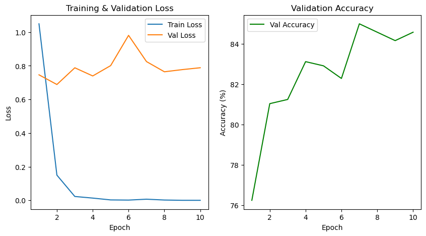

```python
# TO BE COMPLETED
# Initialize model
device = torch.device("cuda" if torch.cuda.is_available() else "cpu")
model = VGGNetFeatureClassifier().to(device)

# Train with train dataset
trained_model = train(model=model, dataset=train_dataset, val_dataset=valid_dataset, num_epochs=10, learning_rate=0.0005, batch_size=64, train=True)
```

```
Test Accuracy: 84.09%
```

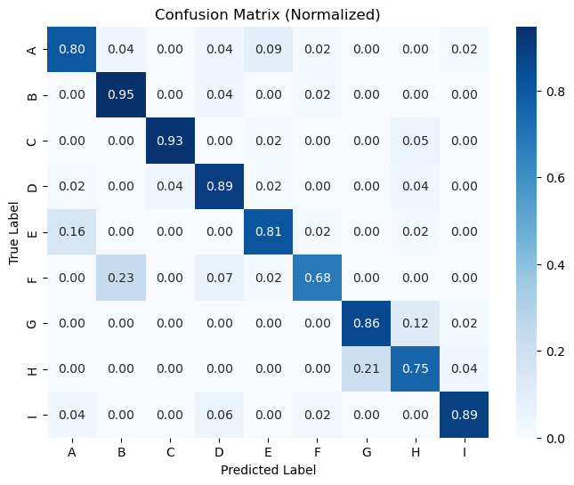

```python
# TO BE COMPLETED
# Test the trained model
test_accuracy = train(model=trained_model, dataset=test_dataset, batch_size=32, train=False)
```

### Part (viii) - [1pt RESULTS]

Compare the performance of AlexNet (Part B4(iv)) and the other pretrained model you selected (Part B4(vii)). Discuss the differences in performance between AlexNet and the new model.

```python
'''
PROVIDE YOUR ANSWER BELOW
The VGG16 model achieved 84.09% accuracy, whereas AlexNet performed slightly better at 88.19%.
This difference may be due to overfitting in VGG16, where the model memorized training patterns but struggled with generalization.
'''
```

## Part 5. Testing on New Data [14pt]

In this final step, we will evaluate the models trained using new data that was not part of the training process. In this assignment, there will be three different test datasets:

1. The test dataset generated by splitting the labeled data provided in the file `A2_Hand_Gesture_Dataset_revised.zip` into train, validation, and test sets. It is used throughout Part B1 to B4.
2. The data you collected in Part A.
3. The unlabeled data provided in `A2_Hand_Gesture_Unlabeled_Data.zip`.

### Part (i) - [2pt EXPLORATORY]

Load and process the hand gesture images you had collected so that they can easily be evaulated by your model.

```python
alexnet = models.alexnet(pretrained=True)
feature_extractor = alexnet.features
feature_extractor.eval()

device = torch.device("cuda" if torch.cuda.is_available() else "cpu")
feature_extractor.to(device)

transform = transforms.Compose([
    transforms.Resize((224, 224)),  # AlexNet input size
    transforms.ToTensor(),
    transforms.Normalize(mean=[0.485, 0.456, 0.406], std=[0.229, 0.224, 0.225])
])

root_folder = r"C:\Users\Austin\Documents\MEng_Courses\MIE1517-Intro-to-Deep-Learning\2_Assignments\A2_CNN\Data_Collection"
feature_dict = {}

# Scan through files in the folder
for filename in files:
    if filename.endswith(".jpg"):
        img_path = os.path.join(root_folder, filename)

        # Use the filename directly
        cleaned_path = filename

        # Load and transform image
        image = Image.open(img_path).convert("RGB")
        image = transform(image).unsqueeze(0).to(device)  # Add batch dimension

        # Extract features
        with torch.no_grad():
            features = feature_extractor(image)  # Get feature maps (1, 256, 6, 6)
            features = features.squeeze(0).cpu().numpy()  # Preserve (256, 6, 6) shape

        # Store features using the cleaned filename
        feature_dict[cleaned_path] = features

# Save extracted features
print(feature_dict)
np.savez("image_features_Alex_self_collected.npz", **feature_dict)
```

```python
import torch
import numpy as np
from torch.utils.data import Dataset

class FeatureDataset(Dataset):
    def __init__(self, feature_file, selected_filenames=None):
        self.features = np.load(feature_file, allow_pickle=True)  # Load .npz file
        self.file_keys = list(self.features.keys())  # Get all stored filenames

        # If specific filenames are provided, filter them
        if selected_filenames:
            self.file_keys = [f for f in self.file_keys if f in selected_filenames]

        # Define label mapping (A → 0, B → 1, ..., I → 8)
        self.label_mapping = {char: idx for idx, char in enumerate("ABCDEFGHI")}

    def __len__(self):
        return len(self.file_keys)

    def __getitem__(self, idx):
        file_name = self.file_keys[idx]  # Get filename
        feature = self.features[file_name]  # Get corresponding feature vector

        # ✅ Extract label from filename (assumed format: "PersonID_ClassID_Extra.jpg")
        class_label_letter = file_name.split("_")[1]  # Extract the letter (e.g., 'A', 'B', ..., 'I')
        class_label = self.label_mapping[class_label_letter]  # Convert letter to number

        return torch.tensor(feature, dtype=torch.float32), torch.tensor(class_label, dtype=torch.long)
```

### Part (ii) - [2pt RESULTS]

Using the best transfer learning model developed in Part 4. Report the test accuracy on your sample images and how it compares to the test accuracy obtained in Part 4(iv)? Also, use your best model from Part 3 to report the test accuracy on the new sample images and how it compares to the test accuracy obtained in Part 3(iv). You should present your results in a pandas DataFrame.

This question will also be evaluated on the overal performance achieved.

```
Test Accuracy: 92.59%
```

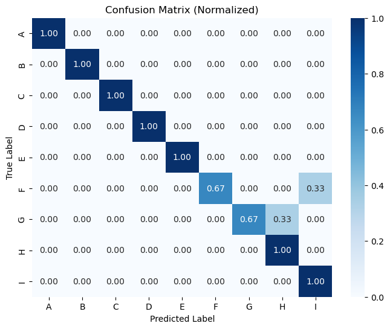

```python
# TO BE COMPLETED
# Path to self-collected dataset features
self_collected_feature_file = "image_features_Alex_self_collected.npz"

# Create dataset for self-collected images (with true labels)
self_collected_test_dataset = FeatureDataset(self_collected_feature_file)

# Create DataLoader
self_collected_test_loader = torch.utils.data.DataLoader(self_collected_test_dataset, batch_size=32, shuffle=False)
self_collected_test_accuracy = train(model=trained_model, dataset=self_collected_test_dataset, batch_size=64, train=False)
```

### Part (iii) - [3pt RESULTS]

Load the unlabeled hand gesture images from the supplementary assignment files on Quercus (`A2_Hand_Gesture_Unlabeled_Data.zip`), which contains 615 unlabeled images. Using the ==best transfer learning== model developed in Part 4, classify all 615 images and save the results in a .CSV file with the following format (Note: The file will be evaluated using an automated Python script to assess your model's performance, so make sure to follow the format precisely).

1. The .csv file must contain exactly 615 lines.
2. Each line should have two comma-separated values: the first value is the image ID number (the filename, e.g., 1 or 123), and the second is the image class (a letter, such as A, B, C, D, E, F, G, H, or I). Do not use spaces or quotation marks.
3. Name your .csv file your student number (Example: 1001234567.csv)

Example .csv file:

```
1,A
2,B
3,C
4,H
...
..
615,I
```

```python
# Load best feature extractor
device = torch.device("cuda" if torch.cuda.is_available() else "cpu")
alexnet = models.alexnet(pretrained=True)
feature_extractor = alexnet.features
feature_extractor.eval()
feature_extractor.to(device)

# Define image transformations (resize + normalize)
transform = transforms.Compose([
    transforms.Resize((224, 224)),  # VGG16 input size
    transforms.ToTensor(),
    transforms.Normalize(mean=[0.485, 0.456, 0.406], std=[0.229, 0.224, 0.225])
])
unlabeled_folder = "shuffled_images"
feature_dict = {}

# Extract features for each image
for filename in sorted(os.listdir(unlabeled_folder), key=lambda x: int(x.split('.')[0])):  # Sort numerically
    if filename.endswith(".jpg"):
        img_path = os.path.join(unlabeled_folder, filename)

        # Load and transform image
        image = Image.open(img_path).convert("RGB")
        image = transform(image).unsqueeze(0).to(device)

        # Extract features
        with torch.no_grad():
            features = feature_extractor(image)  # Shape: (1, 512, 7, 7)
            features = features.squeeze(0).cpu().numpy()  # Flatten to (1, 25088)

        # Store features using filename (without extension)
        image_id = os.path.splitext(filename)[0]  # Get ID (e.g., "1" -> "1.jpg")
        feature_dict[image_id] = features

# Save extracted features to .npz file
np.savez("image_features_Alex_unlabelled", **feature_dict)
```

```python
class UnlabeledFeatureDataset(Dataset):
    def __init__(self, feature_file):
        """
        Load extracted features for unlabeled images.
        """
        self.features = np.load(feature_file, allow_pickle=True)
        self.file_keys = sorted(self.features.keys(), key=lambda x: int(x))

    def __len__(self):
        return len(self.file_keys)

    def __getitem__(self, idx):
        file_name = self.file_keys[idx]
        feature = self.features[file_name]
        return torch.tensor(feature, dtype=torch.float32), file_name
unlabeled_dataset = UnlabeledFeatureDataset("image_features_Alex_unlabelled.npz")
unlabeled_loader = DataLoader(unlabeled_dataset, batch_size=32, shuffle=False)
```

```python
def evaluate_unlabeled(model, dataset, batch_size=32, device=None, output_csv="predictions.csv"):
    if device is None:
        device = torch.device("cuda" if torch.cuda.is_available() else "cpu")

    model.to(device)
    model.eval()

    # Define DataLoader
    data_loader = DataLoader(dataset, batch_size=batch_size, shuffle=False)

    # Class mapping (0 -> A, 1 -> B, ..., 8 -> I)
    idx_to_class = {idx: char for idx, char in enumerate("ABCDEFGHI")}

    predictions = []

    # Perform inference
    with torch.no_grad():
        for features, image_ids in data_loader:
            features = features.to(device)  # Move to device
            outputs = model(features)  # Predict
            _, predicted_labels = torch.max(outputs, 1)  # Get predicted class index

            # Convert predictions to class letters (A-I)
            for img_id, pred_idx in zip(image_ids, predicted_labels.cpu().numpy()):
                predictions.append((img_id, idx_to_class[pred_idx]))

    # Save predictions to CSV file
    with open(output_csv, "w", newline="") as file:
        writer = csv.writer(file)
        writer.writerows(predictions)  # Write (image_id, predicted_class)

    print(f"Predictions saved to {output_csv} successfully!")

    return predictions  # Return predictions as a list

test_accuracy = evaluate_unlabeled(model=trained_model, dataset=unlabeled_dataset, batch_size=32)
```

```
Predictions saved to predictions.csv successfully!
```

### Part (iv) - [5pt DISCUSSION]

How well did your models do for the different hand guestures? Provide an explanation for why you think your models performed the way it did? Be sure to compare the results for three test datasets mentioned in part B5. You can refer to the confusion matrices presented earlier.

How well would this model perform if you were to deploy it in the real-world? List some things you could do to improve the model performance.

```python
'''
PROVIDE YOUR ANSWER BELOW
From the three confusion matrices we plotted, we can observe that the models showed lower accuracy when classifying gestures in the pairs of
(A, E), (B, F), and (G, H).
Upon visual inspection, these gestures have structurally similar hand shapes, making them harder to distinguish by the model.

In real-world scenarios, the model is likely to perform poorly for several reasons:
1. The dataset was acquired in a controlled enviornment (e.g., white background, consistent lightning...etc).
2. The dataset size is limited, making it difficult to generalize across different lighting, backgrounds, and hand variations.
To enhance performance, we could focus on data augmentation, collecting more diverse training samples, and incorporating additional feature
engineering to improve robustness in varied conditions.
'''
```

### Part (v) - [2pt DISCUSSION]

Reflect on the ethical implications of deploying a hand gesture recognition model in real-world applications. What are some potential biases that could arise in your model, and how might they impact different user groups?

Discuss measures you can take to identify and mitigate these biases during the development and deployment phases. Consider aspects such as data collection, model training, and user feedback.

```python
'''
PROVIDE YOUR ANSWER BELOW
One of the most significant biases that can arise in hand gesture recognition is related to skin tone differences. Since pixel intensity varies
significantly based on skin color, a model trained primarily on dark-skinned hands may struggle to recognize light-skinned hands, and vice versa.
This could lead to incorrect classifications or lower accuracy for underrepresented groups, making the system feel unfair or discriminatory.
Additionally, if we attempt to train the model on a diverse set of skin tones, we might introduce other accuracy challenges, such as
balancing performance across all groups without overfitting to one, or the different skin tone under various lighting conditions.

To mitigate these biases, we can collect more data to increase the robustness of the model, or apply data augmentation to simulate different
real-world lighting conditions.
'''
```

# PART C (Optional) - Bonus Challenge!

This is an optional exercise for those that finish the assignment early and would like to take on some additional challenging task.

For this bonus challenge you are asked to explore different techniques to further improve the model for more realistic scenarios where the hands may be in front of various backgrounds, be taken at different scales, rotations, and positions in the image. To build a superior image classification model you can complete one or all of the following tasks.

Tasks:

1. Test your best models (with or without transfer learning) on hand gestures images with backgrounds that are not clean and smooth. You can take your own hand gesture images, or find ones online to test your model. Comment on the performance of your model.
2. Generated additional data by performing data augmentation to replace the clean, smooth backgrounds with backgrounds with different textures. Do this on all your training, validation, and test data. This task can be done manually (could take a long time) or you can implement code that can automate the task. For Example, one approach you could take to automate this task is to use pretrained image segmentation tools to identify the hands in the images and crop them out and put them onto other backgrounds.
3. Implement one of many region proposal tools to detect hand gestures in image frames and put a bounding box around the region with the highest confidence. You can use pretrained YOLO models, or a region proposal tool from openCV.
4. Create a short video demonstration how you can use your hand gesture recognition model to communicate a message using hand gestures.

Bonus marks will be provided based on the number of steps completed. Summarize below your results and anything intersting you learned from the steps that you completed. Bonus marks cannot be accumulated beyond the maximum assignment grade.

```python
# TO BE COMPLETED
```

```python
'''
PROVIDE YOUR ANSWER BELOW






'''
```

### Saving to HTML

Detailed instructions for saving to HTML can be found [here](https://stackoverflow.com/questions/53460051/convert-ipynb-notebook-to-html-in-google-colab/64487858#64487858). Provided below are a summary of the instructions:

(1) download your ipynb file by clicking on File->Download.ipynb

(2) reupload your file to the temporary Google Colab storage (you can access the temporary storage from the tab to the left)

(3) run the following:

```python
from google.colab import drive
drive.mount('/content/drive')
```

```python
%%shell
jupyter nbconvert --to html /content/drive/MyDrive/MIE1517-TA-2025/A2.ipynb
```

(4) the html file will be available for download in the temporary Google Colab storage

(5) review the html file and make sure all the results are visible before submitting your assignment to Quercus

# Assignment Grading Rubric

The grading of the assignment will be based on the following categories:

(0) **5 Pt - DATA** Generating new data to evaluate your model.

(1) **9 Pt - EXPLORATORY QUESTIONS** These are basic questions that in most cases can be answered without requiring a fully working and trained neural network model. For example, data loading, processing and visualization, summary statistics, data exploration, model and training setup, etc.

(2) **9 Pt - MODEL** Student has successfully implemented all the required neural network models and has demonstrated successful training of the model without any errors.

(3) **9 Pt - RESULT** Students are evaluated based on the results achieved in comparison to the expected results of the assignment.

(4) **9 Pt - DISCUSSION QUESTIONS** Student demonstrated understanding beyond the basic exploratory questions, can answer some of the more challenging questions, and provide arguments for their model selection decisions.

(5) **9 Pt - COMMUNICATION** Student has provided a quality submission that is easy to read without too many unnecessary output statements that distract the reading of the document. The code has been well commented and all the answers are communicated clearly and concisely.

(6) **5 Pt - BONUS** Student has completed the assignment and has taken on the challenging bonus tasks listed in PART C. The student has demonstrated a good understanding of all aspects of the assignment and has exceeded expectations for the assignment.

**TOTAL GRADE = _____ of 50 Pts**